# Activity Monitoring

Carlos Ruiz

Friday, November 14, 2014

Load the ggplot2 library

```r
library("ggplot2")
```

Set locale to avoid different month and weekday names

```r
Sys.setlocale("LC_TIME", "English")
```

```
## [1] "English_United States.1252"
```

## Loading and preprocessing the data

### Loading data

Read the **activity.csv** file with the activity data. We assume that the file resides in the current working directory. The default parameters are just fine

```r
activity.data <- read.csv("activity.csv")
```

### Transform data

We need to transform the **date** column to **Date** type

```r
activity.data[, "date"] <- as.Date(activity.data[, "date"], format = "%Y-%m-%d")
```

## Questions

### Mean total number of steps taken per day

Total number of steps taken each day

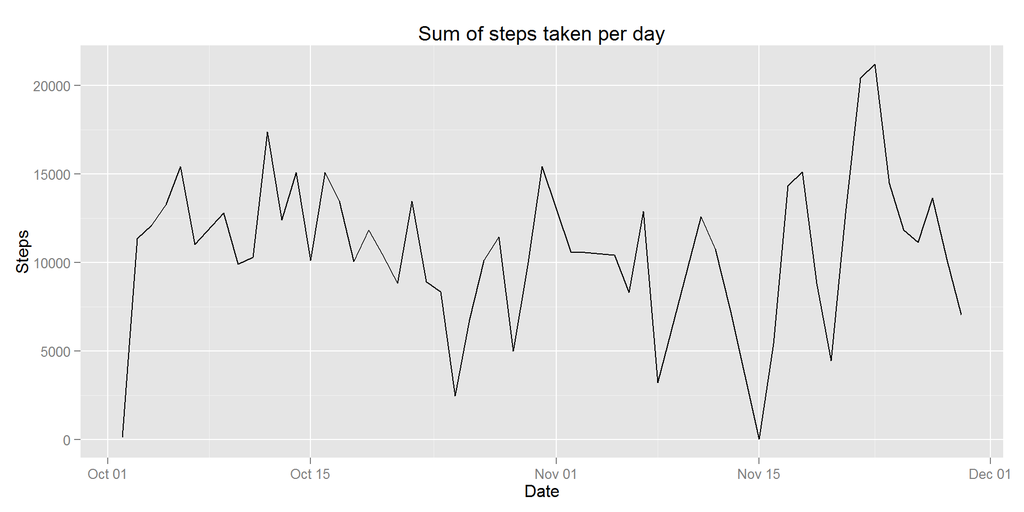

```r
# group by date and report the sum of steps taken per day
sum.steps.by.date <- aggregate(steps ~ date, data = activity.data, sum)

# plot the sum
with (sum.steps.by.date, {
    qplot(
       date,
       steps,
       main = "Sum of steps taken per day",
       xlab = "Date",
       ylab = "Steps",
       geom = "line"
    )
})
```

```r
# print the aggregated data
sum.steps.by.date
```

```
##          date steps
## 1  2012-10-02   126
## 2  2012-10-03 11352
## 3  2012-10-04 12116
## 4  2012-10-05 13294
## 5  2012-10-06 15420
## 6  2012-10-07 11015
## 7  2012-10-09 12811
## 8  2012-10-10  9900
## 9  2012-10-11 10304
## 10 2012-10-12 17382
## 11 2012-10-13 12426
## 12 2012-10-14 15098
## 13 2012-10-15 10139
## 14 2012-10-16 15084
```

[output cut: 39 more lines]

The following is the mean of the total number of steps

```r
mean.steps <- mean(sum.steps.by.date$steps)
mean.steps
```

```
## [1] 10766.19
```

The following is the median of the total number of steps

```r
median.steps <- median(sum.steps.by.date$steps)
median.steps
```

```
## [1] 10765
```

Mean and median of the total number of steps taken per day

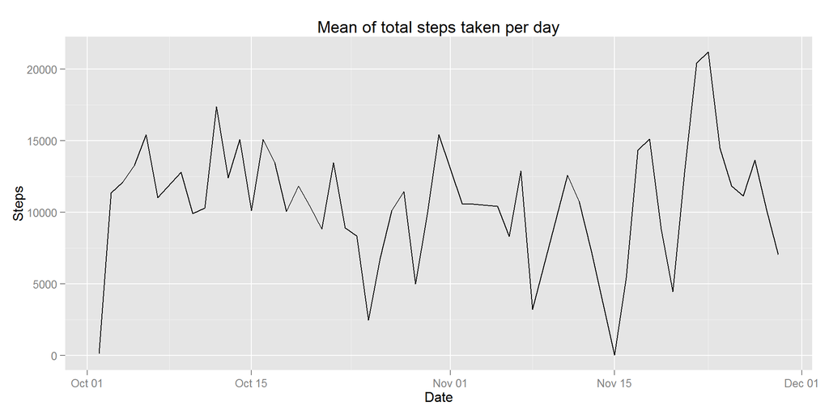

```r
# group by date and report the mean of steps taken per day
mean.steps.by.date <- aggregate(steps ~ date, data = sum.steps.by.date, mean)

# plot the mean
with (mean.steps.by.date, {
    qplot(
        date,
        steps,
        main = "Mean of total steps taken per day",
        xlab = "Date",
        ylab = "Steps",
        geom = "line"
    )
})
```

```r
# print the aggregated data
mean.steps.by.date
```

```
##          date steps
## 1  2012-10-02   126
## 2  2012-10-03 11352
## 3  2012-10-04 12116
## 4  2012-10-05 13294
## 5  2012-10-06 15420
## 6  2012-10-07 11015
## 7  2012-10-09 12811
## 8  2012-10-10  9900
## 9  2012-10-11 10304
## 10 2012-10-12 17382
## 11 2012-10-13 12426
## 12 2012-10-14 15098
## 13 2012-10-15 10139
## 14 2012-10-16 15084
```

[output cut: 39 more lines]

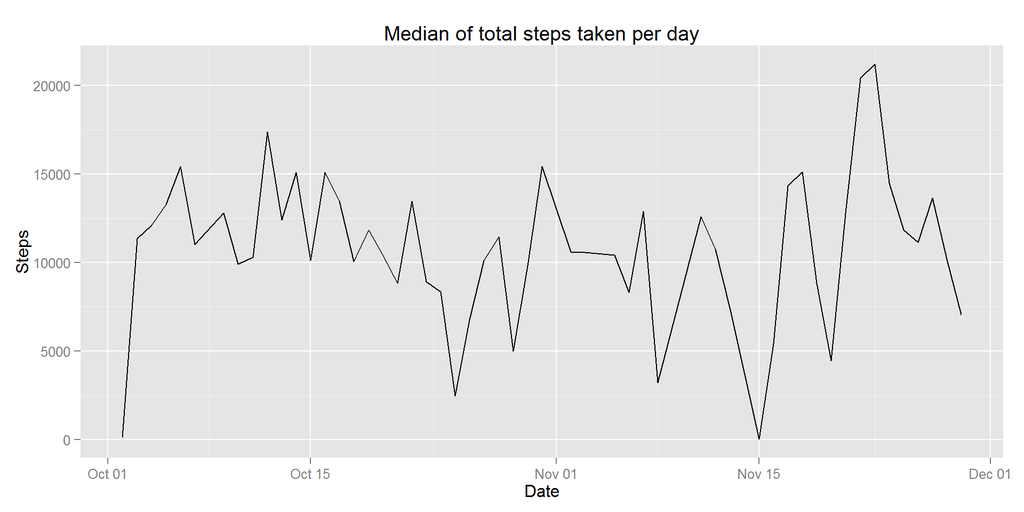

```r
# group by date and report the median of steps taken per day
median.steps.by.date <- aggregate(steps ~ date, data = sum.steps.by.date, median)

# plot the median
with (median.steps.by.date, {
    qplot(
        date,
        steps,
        main = "Median of total steps taken per day",
        xlab = "Date",
        ylab = "Steps",
        geom = "line"
    )
})
```

```r
# print the aggregated data
median.steps.by.date
```

```
##          date steps
## 1  2012-10-02   126
## 2  2012-10-03 11352
## 3  2012-10-04 12116
## 4  2012-10-05 13294
## 5  2012-10-06 15420
## 6  2012-10-07 11015
## 7  2012-10-09 12811
## 8  2012-10-10  9900
## 9  2012-10-11 10304
## 10 2012-10-12 17382
## 11 2012-10-13 12426
## 12 2012-10-14 15098
## 13 2012-10-15 10139
## 14 2012-10-16 15084
```

[output cut: 39 more lines]

### Average daily activity pattern

Time series plot of the 5-minute interval and the average number of steps taken averaged across all days

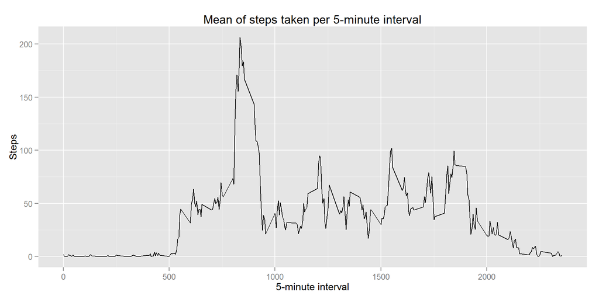

```r
# group by interval and report the mean of steps taken per day
mean.steps.by.interval <- aggregate(steps ~ interval, data = activity.data, mean)

# plot the mean
with (mean.steps.by.interval, {
    qplot(
        interval,
        steps,
        main = "Mean of steps taken per 5-minute interval",
        xlab = "5-minute interval",
        ylab = "Steps",
        geom = "line"
    )
})
```

```r
# print the aggregated data
mean.steps.by.interval
```

```
##     interval       steps
## 1          0   1.7169811
## 2          5   0.3396226
## 3         10   0.1320755
## 4         15   0.1509434
## 5         20   0.0754717
## 6         25   2.0943396
## 7         30   0.5283019
## 8         35   0.8679245
## 9         40   0.0000000
## 10        45   1.4716981
## 11        50   0.3018868
## 12        55   0.1320755
## 13       100   0.3207547
## 14       105   0.6792453
```

[output cut: 274 more lines]

The following 5-minute interval on average accross all the days in the dataset contains the maximum number of steps

```r
mean.steps.by.interval[mean.steps.by.interval[, "steps"] == max(mean.steps.by.interval[, "steps"]), ]
```

```
##     interval    steps
## 104      835 206.1698
```

### Imputing missing values

Total number of missing values in the dataset

```r
sum(is.na(activity.data[, "steps"]))
```

```
## [1] 2304
```

The **strategy** choosen to fill the NA steps values will be the **mean of each 5-minute interval** for the same 5-minute interval

```r
# merge by 5-minute interval to be able to replace the NA values with the mean
filled.activity.data <- merge(
    activity.data,
    mean.steps.by.interval,
    by.x = "interval",
    by.y = "interval"
)

# assign the means of each 5-minute interval where steps value are NA
filled.activity.data[is.na(filled.activity.data[, "steps.x"]), "steps.x"] <-
    filled.activity.data[is.na(filled.activity.data[, "steps.x"]), "steps.y"]
```

Total number of steps taken each day when filling NA values

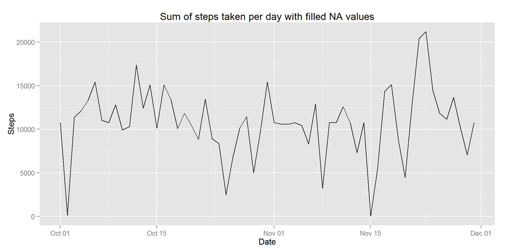

```r
# group by date and report the sum of steps taken per day
filled.sum.steps.by.date <- aggregate(steps.x ~ date, data = filled.activity.data, sum)

# plot the sum
with (filled.sum.steps.by.date, {
    qplot(
        date,
        steps.x,
        main = "Sum of steps taken per day with filled NA values",
        xlab = "Date",
        ylab = "Steps",
        geom = "line"
    )
})
```

```r
# print the aggregated data
filled.sum.steps.by.date
```

```
##          date  steps.x
## 1  2012-10-01 10766.19
## 2  2012-10-02   126.00
## 3  2012-10-03 11352.00
## 4  2012-10-04 12116.00
## 5  2012-10-05 13294.00
## 6  2012-10-06 15420.00
## 7  2012-10-07 11015.00
## 8  2012-10-08 10766.19
## 9  2012-10-09 12811.00
## 10 2012-10-10  9900.00
## 11 2012-10-11 10304.00
## 12 2012-10-12 17382.00
## 13 2012-10-13 12426.00
## 14 2012-10-14 15098.00
```

[output cut: 47 more lines]

The following is the mean of the total number of steps when filling NA values

```r
filled.mean.steps <- mean(filled.sum.steps.by.date$steps)
filled.mean.steps
```

```
## [1] 10766.19
```

The following is the median of the total number of steps when filling NA values

```r
filled.median.steps <- median(filled.sum.steps.by.date$steps)
filled.median.steps
```

```
## [1] 10766.19
```

Mean and median of the total number of steps taken per day when filling NA values

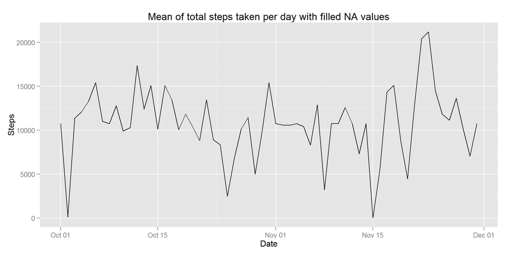

```r
# group by date and report the mean of steps taken per day
filled.mean.steps.by.date <- aggregate(steps.x ~ date, data = filled.sum.steps.by.date, mean)

# plot the mean
with (filled.mean.steps.by.date, {
    qplot(
        date,
        steps.x,
        main = "Mean of total steps taken per day with filled NA values",
        xlab = "Date",
        ylab = "Steps",
        geom = "line"
    )
})
```

```r
# print the aggregated data
filled.mean.steps.by.date
```

```
##          date  steps.x
## 1  2012-10-01 10766.19
## 2  2012-10-02   126.00
## 3  2012-10-03 11352.00
## 4  2012-10-04 12116.00
## 5  2012-10-05 13294.00
## 6  2012-10-06 15420.00
## 7  2012-10-07 11015.00
## 8  2012-10-08 10766.19
## 9  2012-10-09 12811.00
## 10 2012-10-10  9900.00
## 11 2012-10-11 10304.00
## 12 2012-10-12 17382.00
## 13 2012-10-13 12426.00
## 14 2012-10-14 15098.00
```

[output cut: 47 more lines]

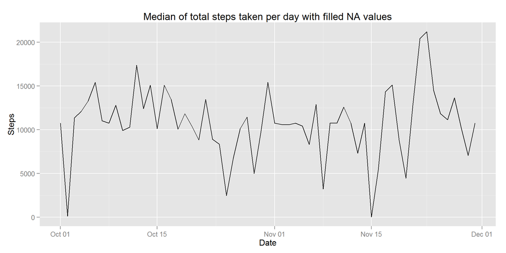

```r
# group by date and report the median of steps taken per day
filled.median.steps.by.date <- aggregate(steps.x ~ date, data = filled.sum.steps.by.date, median)

# plot the median
with (filled.median.steps.by.date, {
    qplot(
        date,
        steps.x,
        main = "Median of total steps taken per day with filled NA values",
        xlab = "Date",
        ylab = "Steps",
        geom = "line"
    )
})
```

```r
# print the aggregated data
filled.median.steps.by.date
```

```
##          date  steps.x
## 1  2012-10-01 10766.19
## 2  2012-10-02   126.00
## 3  2012-10-03 11352.00
## 4  2012-10-04 12116.00
## 5  2012-10-05 13294.00
## 6  2012-10-06 15420.00
## 7  2012-10-07 11015.00
## 8  2012-10-08 10766.19
## 9  2012-10-09 12811.00
## 10 2012-10-10  9900.00
## 11 2012-10-11 10304.00
## 12 2012-10-12 17382.00
## 13 2012-10-13 12426.00
## 14 2012-10-14 15098.00
```

[output cut: 47 more lines]

Comparing the original mean and median against the mean and median with filled NA values

```r
cat(mean.steps, filled.mean.steps)
```

```
## 10766.19 10766.19
```

```r
cat(median.steps, filled.median.steps)
```

```
## 10765 10766.19
```

### Differences in activity patterns between weekdays and weekends

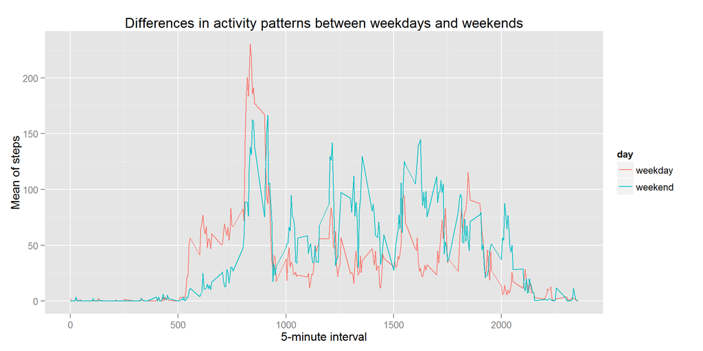

```r
# get the weekday from date column
filled.activity.data[, "day"] <- weekdays(filled.activity.data[, "date"], TRUE)

# assign weekends
filled.activity.data[filled.activity.data[, "day"] %in% c("Sat", "Sun"), "day"] <- "weekend"

# assign weekdays
filled.activity.data[filled.activity.data[, "day"] != "weekend", "day"] <- "weekday"

# group by interval and day
filled.mean.steps.by.interval <- aggregate(steps.x ~ interval + day, data = filled.activity.data, mean)

# plot the mean
with (filled.mean.steps.by.interval, {
    qplot(
        interval,
        steps.x,
        facet = day,
        main = "Differences in activity patterns between weekdays and weekends",
        xlab = "5-minute interval",
        ylab = "Mean of steps",
        geom = "line",
        color = day
    )
})
```

```r
# print the aggregated data
filled.mean.steps.by.interval
```

```
##     interval     day      steps.x
## 1          0 weekday 2.251153e+00
## 2          5 weekday 4.452830e-01
## 3         10 weekday 1.731656e-01
## 4         15 weekday 1.979036e-01
## 5         20 weekday 9.895178e-02
## 6         25 weekday 1.590356e+00
## 7         30 weekday 6.926625e-01
## 8         35 weekday 1.137945e+00
## 9         40 weekday 0.000000e+00
## 10        45 weekday 1.796226e+00
## 11        50 weekday 3.958071e-01
## 12        55 weekday 1.761006e-02
## 13       100 weekday 4.205451e-01
## 14       105 weekday 9.056604e-02
```

[output cut: 562 more lines]

There are some differences in several 5-minute intervals when the day are a weekend day. I decided to plot both the weekdays and the weekends in the same plot to be able to compare easily